# cs100 Studio 3

Robert and Sabrina

October 6, 2016

install.packages(“dplyr”) install.packages(“ggplot2”) install.packages(“mosaic”)

hypothesis 1

```r
friends_vs_happiness <- responses %>%
  select(Number.of.friends,   Happiness.in.life) %>%
  arrange(desc(Number.of.friends))
```

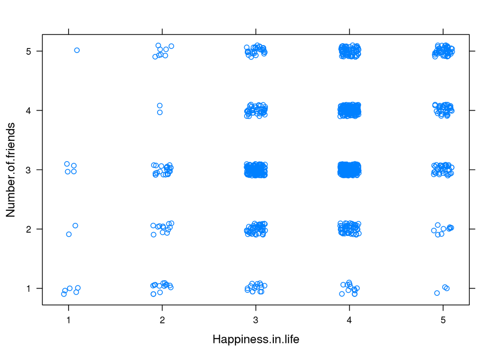

```r
 xyplot( Number.of.friends ~ Happiness.in.life, data = friends_vs_happiness, main="", jitter.x=TRUE, jitter.y=TRUE)
```

people who have 3-5 friends seem to be happier than those who have 1-2 friends

hypothesis 2

```r
gender_vs_happiness <- responses %>%
  select(Gender, Happiness.in.life) %>%
  arrange(desc(Gender))
```

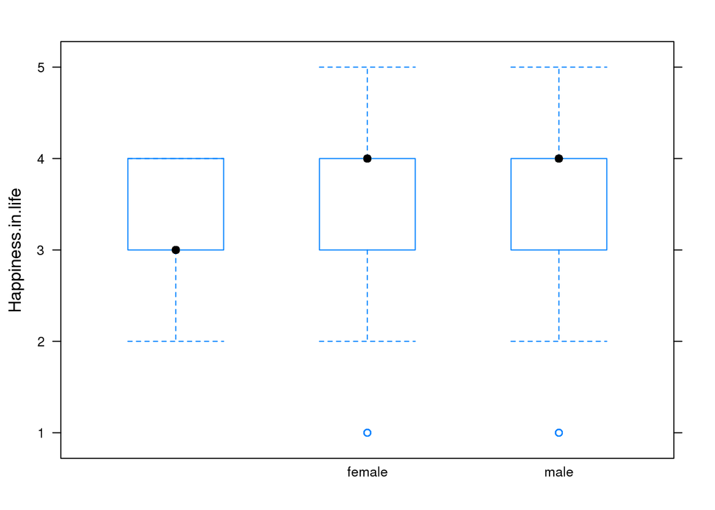

```r
bwplot( Happiness.in.life ~ Gender, data = gender_vs_happiness, main="")
```

both genders have around the same 2nd and 3rd quartile, and a very similar average selection of happiness levels.

hypothesis 3

```r
happiness_vs_age <- responses %>%
  select(Age, Happiness.in.life) %>%
  na.omit()%>%
  group_by(Age)%>%
  summarise(avg_happiness=mean(Happiness.in.life))%>%
  arrange(desc(Age))
```

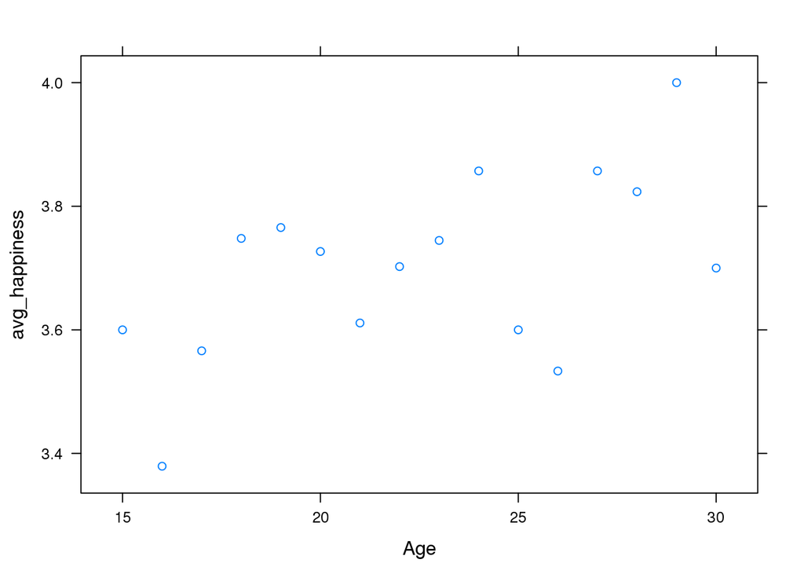

```r
xyplot( avg_happiness ~ Age, data = happiness_vs_age, main="")
```

There seems to be positive correlation between increasing age and average happiness level.

hypothesis4- compassion to animals vs. loneliness

```r
compassion_vs_loneliness <- responses %>%
  select(Compassion.to.animals, Loneliness) %>%
  na.omit()%>%
  group_by(Compassion.to.animals)%>%
  arrange(desc(Compassion.to.animals))
```

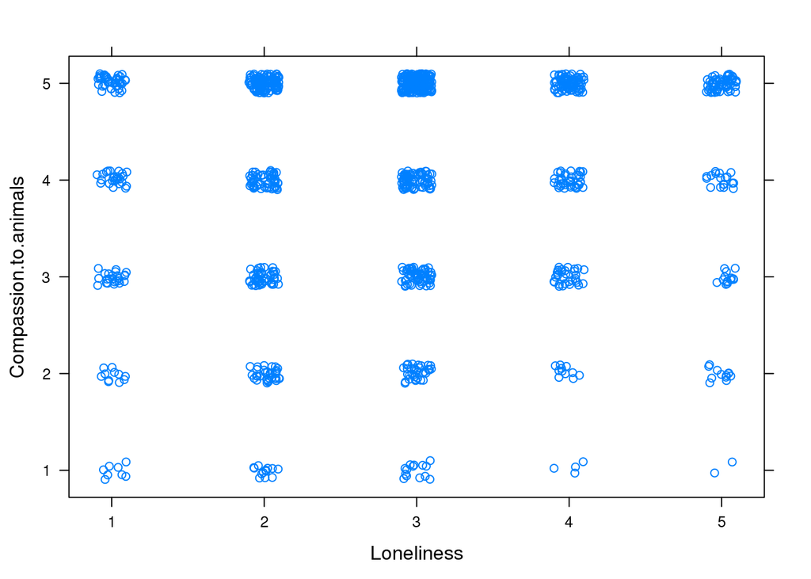

```r
 xyplot( Compassion.to.animals ~ Loneliness, data = compassion_vs_loneliness, main="", jitter.x=TRUE, jitter.y=TRUE)
```

it seems that no matter what loneliness level people really just like animals– theyre nice to them :)

hypothesis5— fear of public speaking and Unpopularity

```r
FearOfPublicSpeaking_vs_unpopularity <- responses %>%
  select(Fear.of.public.speaking, Unpopularity) %>%
  na.omit()%>%
  group_by(Fear.of.public.speaking)%>%
  arrange(desc(Fear.of.public.speaking))
```

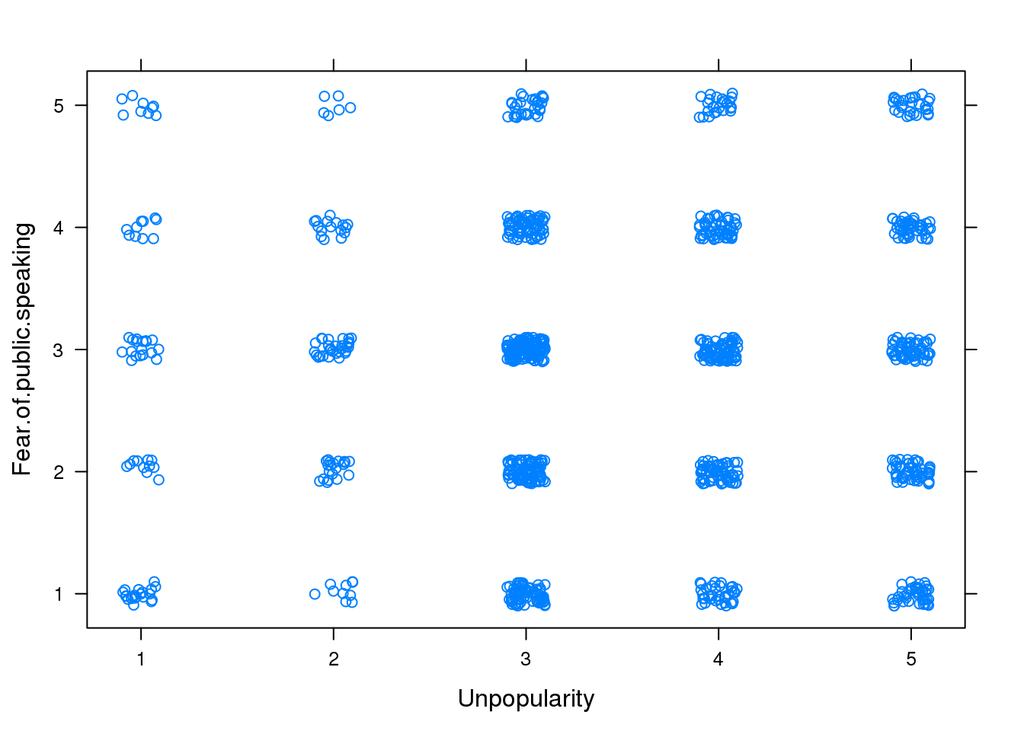

```r
 xyplot( Fear.of.public.speaking ~ Unpopularity, data = FearOfPublicSpeaking_vs_unpopularity, main="", jitter.x=TRUE, jitter.y=TRUE)
```

it seems like if you are of average unpopularity youare moderately scared of public speaking- all in al lthe more popular you are the less youre scared of public speaking

hypothesis6— ageing vs. smoking

```r
Ageing_vs_smoking <- responses %>%
  select(Ageing, Smoking) %>%
  na.omit()%>%
  group_by(Ageing)%>%
  arrange(desc(Ageing))
```

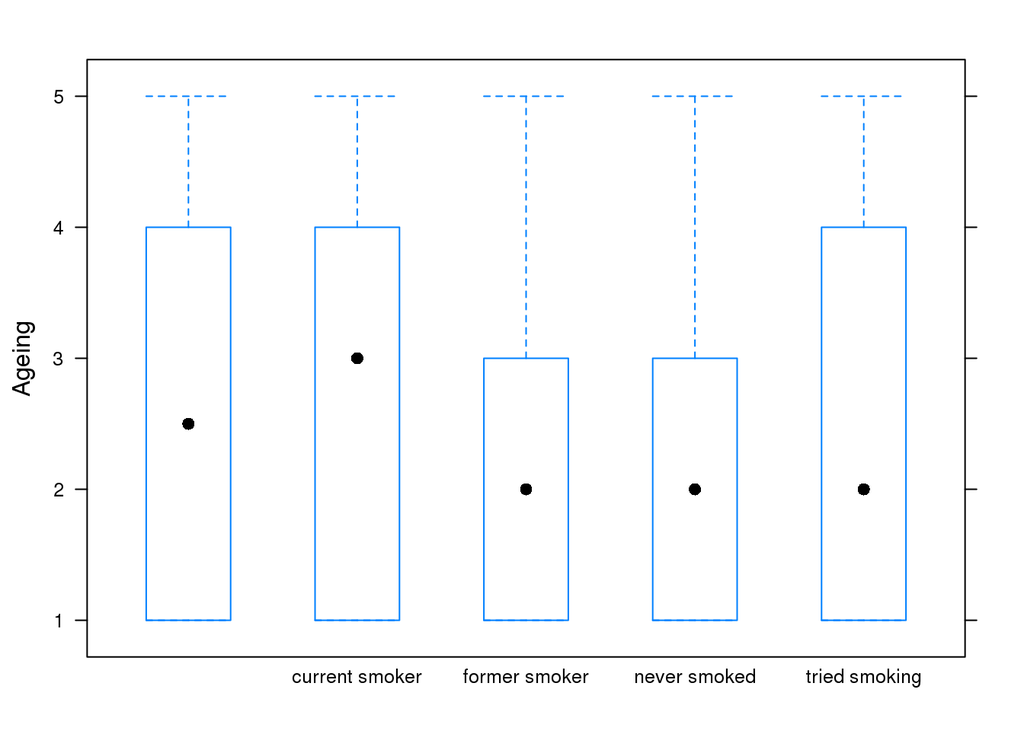

```r
 bwplot( Ageing ~ Smoking, data = Ageing_vs_smoking, main="")
```

there is a bigger range among people who are ageing more, and on average current smokers have a higher ageing average.